# South Sudan Resilience

Preliminary data review

Oct 2021

# 1 Introduction

The South Sudan Monitoring and Evaluation Support Project (MESP) is conducting a household resilience survey in 13 counties. The purpose of this household survey is to obtain baseline data in the target areas for the indicators included in the Mission’s Performance Management Plan (PMP) and the Community Roadmap, in support of USAID/South Sudan’s Strategic Framework (2020-2024).

MESP has completed data collection in six counties, and as of October 2021 is carrying out data collection in the remaining seven counties. The study team is currently reviewing the data from six counties in advance of analysis of the full set of 13 counties. This document reviews a selection of measures and indices relating to resilience.

# 2 Resilience measures

The United States Agency for International Development (USAID) defines resilience as the ability of people, households, communities, countries, and systems to mitigate, adapt to and recover from shocks and stresses in a manner that reduces chronic vulnerability and facilitates inclusive growth [(Measuring Resilience in USAID)](https://www.usaid.gov/sites/default/files/documents/1866/Technical%20Note_Measuring%20Resilience%20in%20USAID_June%202013.pdf). For USAID-funded activities, resilience is operationalized as a set of capacities that mediate the interaction of shocks and stresses on a measure of household well-being [(Tango International 2018)](https://www.fsnnetwork.org/sites/default/files/Methodology_Guide_Nov2018508.pdf).

Common well-being measures include poverty, food insecurity, child wasting, and self-perceived ability to recover from shocks or stresses. Shocks and stresses are measured across a range of specific events (shocks) or risks (stresses) and aggregated to a single measure of exposure. Capacities are measured along three primary indices, with each dimension consisting of its own set of sub-indices:

- **Absorptive capacity**
  - Access to informal safety nets
  - Bonding social capital
  - Access to cash savings
  - Access to remittances
  - Asset ownership
  - Shock preparedness and mitigation
  - Access to insurance
  - Access to humanitarian/development assistance
- **Adaptive capacity**
  - Bridging social capital
  - Linking social capital
  - Social network index
  - Education/training
  - Livelihood diversification
  - Exposure to information
  - Adoption of improved practices
  - Asset ownership
  - Availability of financial services
  - Aspirations/confidence to adapt/locus of control
- **Transformative capacity**
  - Access to formal safety nets
  - Access to markets
  - Access to communal natural resources
  - Access to basic services
  - Access to infrastructure
  - Access to livestock services
  - Bridging social capital
  - Linking social capital
  - Collective action
  - Social cohesion
  - Gender equitable decision-making index
  - Participation in local decision-making
  - Local government responsiveness
  - Gender index

The Food and Agricultural Organization (FAO) also has a methodology for measuring resilience [(FAO 2016)](http://www.fao.org/3/i5665e/i5665e.pdf), which adds measures such as dietary diversity as a complement to food insecurity.

The South Sudan resilience study reviewed this list of outcomes, shocks, and capacities and selected a subset of them for measuring resilience:

- Aspirations index
- Dietary diversity
- Bonding social capital
- Bridging social capital
- Food insecurity
- Shocks and stresses
- Belief in local government support
- Social norms

This document will conduct preliminary review of these measures, using household survey data in six counties.

# 3 Resilience data

The data comes from a household survey in the counties of Akobo, Budi, Duk, Leer, Pibor, and Uror, using a two-stage sampling procedure where the sampling points, referred to as enumeration areas (EAs), are randomly selected within each county, and households are randomly selected within each EA. The following map illustrates the sampling points across all six counties.

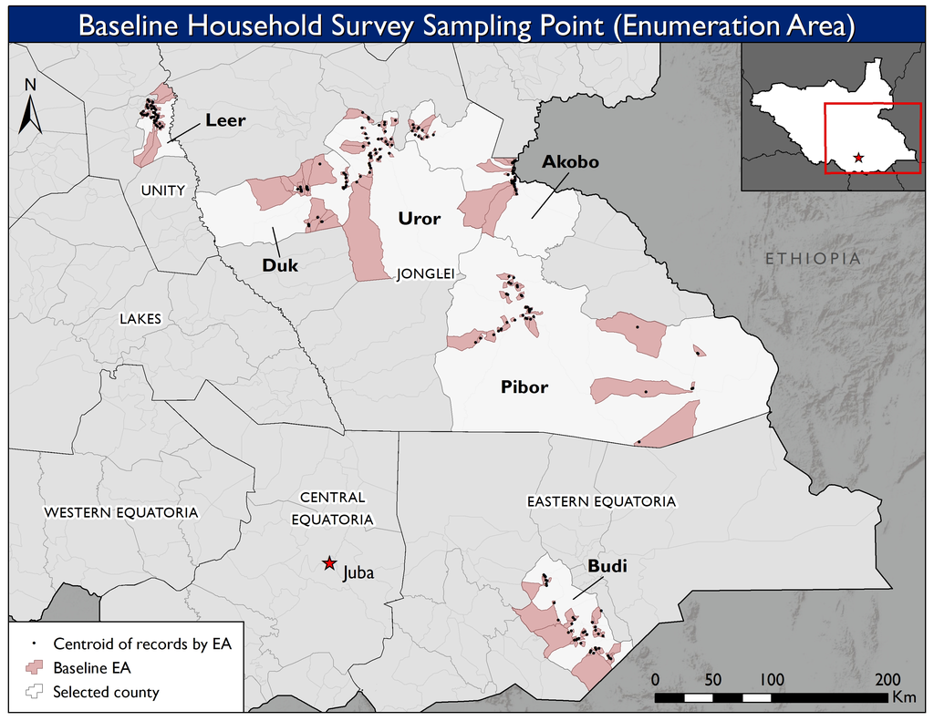

```r
include_graphics(here("exploratory analysis/viz/maps/MESP_HH_Survey_Sampling_Point_ALL.jpg"))
```

A total sample size of 3,563 households were apportioned relatively evenly across the six counties.

```r
smpl <- svyrdat %>%
  group_by(County=county) %>%
  summarize(`Population`=survey_total(),
            `Sample`=unweighted(n())) %>%
  select(1,2,4)

smpl_gt <- smpl %>%
  gt() %>%
  fmt_number(2:3,
             decimals=0)

smpl_gt
```

| County | Population | Sample |
| --- | --- | --- |
| Akobo | 11,434 | 625 |
| Budi | 13,071 | 620 |
| Duk | 6,275 | 518 |
| Leer | 5,716 | 620 |
| Pibor | 36,526 | 564 |
| Uror | 39,354 | 616 |

Under simple random sampling, and using the measure of belief in local government support in the face of shocks and stresses, the overall margin of error of the survey would be 1.9 percent, per the following table.

```r
dat %>%
  summarize(mn = mean(resil_c, na.rm=T),
            std.err = std.error(resil_c, na.rm=T),
            margin = 1.96*std.err)
```

| mn | std.err | margin |
| --- | --- | --- |
| 0.409 | 0.00967 | 0.0189 |

Given the clustered nature of the data collection, the complex margin of error overall is 5.9 percent, per the following table:

```r
svymean(~resil_c,
        na.rm=T,
        deff="replace",
        design=svydat) %>%
  as.data.frame() %>%
  mutate(Margin = 1.96*resil_c,
         deft=sqrt(deff))
```

| mean | resil_c | deff | Margin | deft |
| --- | --- | --- | --- | --- |
| 0.351 | 0.0302 | 10.3 | 0.0592 | 3.22 |

Across county, the simple margin of error ranges from 3.5 - 5.5 percent, per the following table:

```r
dat %>%
  group_by(county) %>%
  summarize(mn=mean(resil_c, na.rm=T),
            se=std.error(resil_c, na.rm=T),
            margin=1.96*se)
```

| county | mn | se | margin |
| --- | --- | --- | --- |
| Akobo | 0.308 | 0.0267 | 0.0524 |
| Budi | 0.622 | 0.0203 | 0.0398 |
| Duk | 0.262 | 0.0197 | 0.0386 |
| Leer | 0.625 | 0.0238 | 0.0466 |
| Pibor | 0.198 | 0.0178 | 0.035 |
| Uror | 0.401 | 0.0282 | 0.0554 |

Accounting for the clustered nature of the data collection, the complex margin of error across county ranges from 3.6 - 19.1 percent, per the following table:

```r
svyrdat %>%
  group_by(county) %>%
  summarize(mn=survey_mean(resil_c, na.rm=T)) %>%
  mutate(margin=1.96*mn_se)
```

| county | mn | mn_se | margin |
| --- | --- | --- | --- |
| Akobo | 0.293 | 0.0431 | 0.0845 |
| Budi | 0.5 | 0.0954 | 0.187 |
| Duk | 0.364 | 0.0977 | 0.191 |
| Leer | 0.63 | 0.0465 | 0.0912 |
| Pibor | 0.202 | 0.0185 | 0.0363 |
| Uror | 0.455 | 0.0862 | 0.169 |

In the exploratory analysis that follows, both weighted or unweighted frequencies may be used. Generally speaking, when reporting an overall measure such as a mean or frequency, weighted measures should be considered as the estimates of their respective population parameters. In other cases where interest may be more in how the measures vary across disaggregations of interest, unweighted measures may be used.

# 4 Aspirations index

Following [(Tango International 2018)](https://www.fsnnetwork.org/sites/default/files/Methodology_Guide_Nov2018508.pdf), the Aspirations index comprises six binary choice survey items, in which respondents either affirm or deny statements relating to their sense of agency in life, or whether the household has concrete plans for the future. The following table shows these items and their overall weighted frequencies.

```r
asp <- svyrdat %>%
  group_by() %>%
  summarize(asp1=mean(asp1, na.rm=T),
            asp2=mean(asp2, na.rm=T),
            asp3=mean(asp3, na.rm=T),
            asp4=mean(asp4, na.rm=T),
            asp5=mean(asp5, na.rm=T),
            asp6=mean(asp6, na.rm=T)) %>%
  t() %>%
  as.data.frame() %>%
  rownames_to_column("var_name") %>%
  mutate(item_num = c("q_629", "q_630", "q_634", "q_635", "q_632", "q_633"),
         Description=c("Each person is responsible for his/her own success or failure in life",
                       "To be successful one needs to work very hard rather than rely on luck",
                        "My experience in life has been that was is going to happen will happen (reverse-coded)",
                        "It is not always good for me to plan too far ahead because many things turn out to be a matter of good or bad fortune (reverse-coded)",
                        "Hopeful for children's future",
                        "Desire for their children to graduate from secondary school")) %>%
   select(var_name, item_num, Description, Percent=V1)

asp
```

| var_name | item_num | Description | Percent |
| --- | --- | --- | --- |
| asp1 | q_629 | Each person is responsible for his/her own success or failure in life | 0.781 |
| asp2 | q_630 | To be successful one needs to work very hard rather than rely on luck | 0.797 |
| asp3 | q_634 | My experience in life has been that was is going to happen will happen (reverse-coded) | 0.342 |
| asp4 | q_635 | It is not always good for me to plan too far ahead because many things turn out to be a matter of good or bad fortune (reverse-coded) | 0.368 |
| asp5 | q_632 | Hopeful for children's future | 0.839 |
| asp6 | q_633 | Desire for their children to graduate from secondary school | 0.916 |

Note the low values for the reverse coded items, suggesting some combination of acquiescence bias (uncritically affirming the implicit premise of the question) or lack of comprehension of a reverse-coded question in which the respondent must disagree with the implicit premise in order to communicate their stance. These reverse-coded items should be considered more critically for inclusion in any index computation.

A simple summation of the six binary items provides an ordered scale ranging from 0-6.

The simple mean and other descriptives

```r
describe(dat$aspirations_index2)
```

| vars | n | mean | sd | median | trimmed | mad | min | max | range | skew | kurtosis | se |
| --- | --- | --- | --- | --- | --- | --- | --- | --- | --- | --- | --- | --- |
| 1 | 3.45e+03 | 4.04 | 1.16 | 4 | 4.07 | 1.48 | 0 | 6 | 6 | -0.254 | -0.0871 | 0.0197 |

The overall weighted value is 3.9 out of six, with a margin of 0.12. The median is four.

```r
svyrdat %>%
  summarize(Aspirations=survey_mean(aspirations_index2, na.rm=T),
            Aspirations_med = survey_quantile(aspirations_index2, .5, na.rm=T)) %>%
  mutate(margin=1.96*Aspirations_se)
```

| Aspirations | Aspirations_se | Aspirations_med_q50 | Aspirations_med_q50_se | margin |
| --- | --- | --- | --- | --- |
| 3.9 | 0.0591 | 4 | 0 | 0.116 |

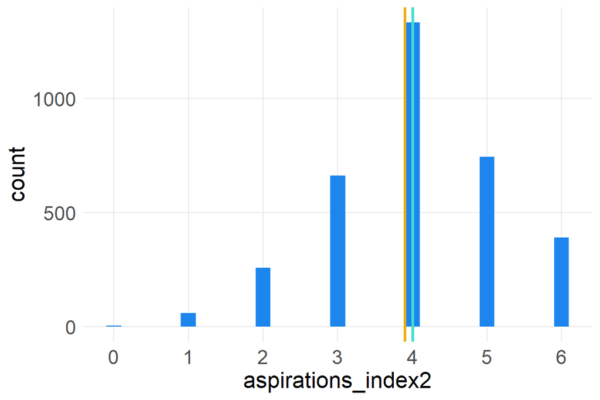

```r
ggplot(dat, aes(aspirations_index2)) +
  geom_bar(width=.2, fill="dodgerblue2") +
  geom_vline(xintercept=3.9, size=1, color="darkgoldenrod2") +
  geom_vline(xintercept=4, size=1, color="turquoise") +
  scale_x_continuous(breaks=0:6)
```

Unweighted values by county.

```r
asp_cnty <- dat %>%
  group_by(county) %>%
  summarize(asp = mean(aspirations_index2, na.rm=T),
            se = std.error(aspirations_index2)) %>%
  mutate(lower=asp-1.96*se,
         upper=asp+1.96*se)

asp_cnty
```

| county | asp | se | lower | upper |
| --- | --- | --- | --- | --- |
| Akobo | 4 | 0.0475 | 3.9 | 4.09 |
| Budi | 4.42 | 0.055 | 4.32 | 4.53 |
| Duk | 3.95 | 0.0342 | 3.89 | 4.02 |
| Leer | 4.38 | 0.0454 | 4.3 | 4.47 |
| Pibor | 3.54 | 0.0349 | 3.47 | 3.61 |
| Uror | 3.89 | 0.0523 | 3.78 | 3.99 |

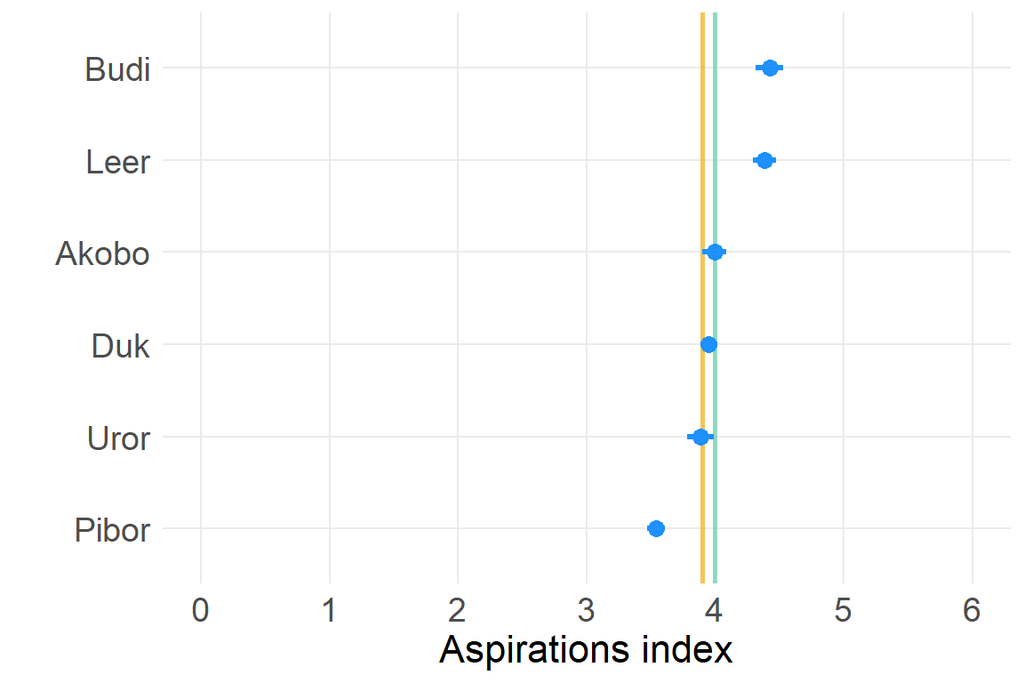

```r
ggplot(asp_cnty, aes(asp, fct_reorder(county, asp))) +
  geom_vline(xintercept=3.9, size=1, alpha=.7, color="darkgoldenrod2") +
  geom_vline(xintercept=4, size=1, alpha=.7, color="aquamarine3") +
  geom_point(color="dodgerblue", size=3) +
  geom_errorbar(aes(xmin=lower, xmax=upper),
                color="dodgerblue",
                width=0,
                size=1.1) +
  scale_x_continuous(limits=c(0,6),
                     breaks=0:6) +
  labs(x="Aspirations index",
       y="")
```

Weighted values by county

```r
asp_cnty_wt <- svyrdat %>%
  group_by(county) %>%
  summarize(asp = survey_mean(aspirations_index2, na.rm=T)) %>%
  mutate(lower=asp-1.96*asp_se,
         upper=asp+1.96*asp_se)

asp_cnty_wt
```

| county | asp | asp_se | lower | upper |
| --- | --- | --- | --- | --- |
| Akobo | 4.04 | 0.104 | 3.84 | 4.24 |
| Budi | 4.56 | 0.116 | 4.33 | 4.79 |
| Duk | 3.99 | 0.0672 | 3.86 | 4.12 |
| Leer | 4.41 | 0.0557 | 4.3 | 4.52 |
| Pibor | 3.54 | 0.0726 | 3.4 | 3.69 |
| Uror | 3.87 | 0.136 | 3.6 | 4.14 |

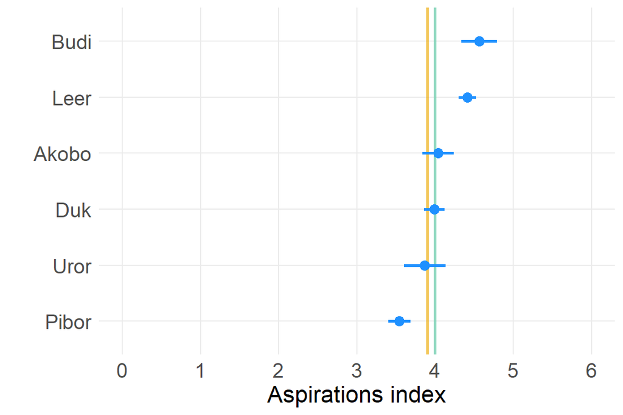

```r
ggplot(asp_cnty_wt, aes(asp, fct_reorder(county, asp))) +
  geom_vline(xintercept=3.9, size=1, alpha=.7, color="darkgoldenrod2") +
  geom_vline(xintercept=4, size=1, alpha=.7, color="aquamarine3") +
  geom_point(color="dodgerblue", size=3) +
  geom_errorbar(aes(xmin=lower, xmax=upper),
                color="dodgerblue",
                width=0,
                size=1) +
  scale_x_continuous(limits=c(0,6),
                     breaks=0:6) +
  labs(x="Aspirations index",
       y="")
```